# Tugas Prak 3 MPDW

Sintya Sulis

2026-09-10

## Pengantar (semua model bisa untuk multiple regression)

Peubah dependen (Y) yang digunakan adalah AQI (Air Quality Index), sedangkan peubah independen (X) yang dipilih adalah O3 (Ozon).

## 1. Persiapan Data

### *Packages*

```r
# Mengaktifkan library yang dibutuhkan
# install.packages(c("dLagM", "dynlm", "MLmetrics", "lmtest", "car")) # Run jika belum meng-install

library(dLagM)
library(dynlm)
library(MLmetrics)
library(lmtest)
library(car)
```

### Impor & Pembagian Data

Data yang digunakan adalah data kualitas udara New Delhi (observasi per jam), dengan AQI sebagai Y dan O3 sebagai X. Data dibagi menjadi data Training (75% data awal) untuk membentuk model dan data Testing (25% data akhir) untuk menguji akurasi ramalan.

```r
# Impor Data
data_awal <- rio::import('/Users/sintyasulis/Downloads/NewDelhi_Air_quality.csv')

data <- data.frame(Yt = data_awal$AQI, Xt = data_awal$o3)

# Membagi data (54 observasi pertama untuk training, 18 observasi terakhir untuk testing)
train <- data[1:54,]
test <- data[55:72,]

# Mengubah format data menjadi objek Time Series (ts)
train.ts <- ts(train)
test.ts <- ts(test)
data.ts <- ts(data)
```

## 2. Model Koyck (PAKAI MLE bukan OLS jadi ga uji asumsi)

Model Koyck mengatasi masalah infinite distributed lag (pengaruh masa lalu yang tak terhingga) dengan mengasumsikan bahwa semakin jauh jarak lag, semakin kecil pengaruhnya.

Melalui transformasi aljabar, efek masa lalu dari X yang sangat panjang diringkas ke dalam satu variabel saja, yaitu $Y_{t-1}$. Bentuk persamaannya menjadi:

$$Y_t=a(1-\lambda)+\beta_0X_t+\lambda
Y_{t-1}+V_t$$
Catatan: $V_t$ adalah error term gabungan. Pada hasil ringkasan model (estimasi), $V_t$ tidak ditampilkan karena nilai harapannya diasumsikan nol.

### Pemodelan

Pemodelan ini menggunakan fungsi `koyckDlm()`.

```r
# Membangun Model Koyck
model.koyck <- koyckDlm(x = train$Xt, y = train$Yt)
summary(model.koyck)
```

```
##
## Call:
## "Y ~ (Intercept) + Y.1 + X.t"
##
## Residuals:
##       Min        1Q    Median        3Q       Max
## -1.135845 -0.266174  0.005908  0.250093  1.063969
##
## Coefficients:
##             Estimate Std. Error t value Pr(>|t|)
## (Intercept)  0.61475    0.92829   0.662    0.511
## Y.1          0.40694    0.07979   5.100 5.25e-06 ***
## X.t          0.26339    0.03991   6.600 2.54e-08 ***
## ---
## Signif. codes:  0 '***' 0.001 '**' 0.01 '*' 0.05 '.' 0.1 ' ' 1
##
## Residual standard error: 0.5015 on 50 degrees of freedom
## Multiple R-Squared: 0.9489,  Adjusted R-squared: 0.9468
## Wald test: 423.5 on 2 and 50 DF,  p-value: < 2.2e-16
##
## Diagnostic tests:
## NULL
##
##                             alpha      beta       phi
## Geometric coefficients:  1.036564 0.2633856 0.4069377
```

**Interpretasi:** *P-value* dari peubah $X_t$ dan $Y_{t-1}$ $< 0.05$, artinya kedua peubah tersebut berpengaruh signifikan terhadap $Y_t$. Koefisien pada $Y_{t-1}$ mewakili parameter $\lambda$ (tingkat penurunan pengaruh).

**Persamaan:**

$$\hat{Y_t}=0.61475+0.26339X_t+0.40694Y_{t-1}$$

### Peramalan

```r
# Meramalkan 18 periode ke depan
fore.koyck <- forecast(model = model.koyck, x = test$Xt, h = 18)
fore.koyck
```

```
## $forecasts
##  [1] 27.04989 26.69341 25.79480 24.48718 23.20150 22.01896 21.16096 20.24664
##  [9] 19.78038 20.06161 20.74121 21.01777 21.13031 21.64708 23.17609 24.92863
## [17] 26.39536 27.36900
##
## $call
## forecast.koyckDlm(model = model.koyck, x = test$Xt, h = 18)
##
## attr(,"class")
## [1] "forecast.koyckDlm" "dLagM"
```

```r
# Cek Akurasi (MAPE) pada data testing
mape.koyck <- MAPE(fore.koyck$forecasts, test$Yt)
cat("MAPE Model Koyck:", mape.koyck, "\n")
```

```
## MAPE Model Koyck: 0.03065559
```

## 3. Regression with Distributed Lag (DLM)

Berbeda dengan Koyck, pemodelan DLM membatasi secara spesifik berapa periode memori masa lalu yang dilibatkan. Batasan ini direpresentasikan dengan parameter $q$.

$$Y_t=\alpha+\beta_0X_t+\beta_1X_{t-1}+…+\beta_qX_{t-q}+e_t$$

### Pemodelan (Lag = 2)

Fungsi yang digunakan adalah `dlm()`. Parameter `q = 2` berarti kita memasukkan $X_t, X_{t-1}$, dan $X_{t-2}$.

```r
model.dlm <- dlm(x = train$Xt, y = train$Yt, q = 2)
summary(model.dlm)
```

```
##
## Call:
## lm(formula = model.formula, data = design)
##
## Residuals:
##      Min       1Q   Median       3Q      Max
## -0.44335 -0.37055 -0.04179  0.26042  1.39418
##
## Coefficients:
##              Estimate Std. Error t value Pr(>|t|)
## (Intercept)  0.007792   0.713903   0.011    0.991
## x.t          0.466554   0.057686   8.088 1.62e-10 ***
## x.1          0.007958   0.104174   0.076    0.939
## x.2         -0.013161   0.057312  -0.230    0.819
## ---
## Signif. codes:  0 '***' 0.001 '**' 0.01 '*' 0.05 '.' 0.1 ' ' 1
##
## Residual standard error: 0.3566 on 48 degrees of freedom
## Multiple R-squared:  0.9751, Adjusted R-squared:  0.9735
## F-statistic: 626.4 on 3 and 48 DF,  p-value: < 2.2e-16
##
## AIC and BIC values for the model:
##        AIC      BIC
## 1 46.15758 55.91379
```

### Penentuan *Lag* Optimum

Untuk menghindari coba-coba, kita bisa mencari nilai $q$ terbaik berdasarkan nilai *Akaike Information Criterion (AIC)* terkecil menggunakan fungsi `finiteDLMauto()`.

```r
finiteDLMauto(formula = Yt ~ Xt,
              data = data.frame(train), q.min = 1, q.max = 10,
              model.type = "dlm", error.type = "AIC", trace = TRUE)
```

```
##    q - k    MASE      AIC      BIC     GMRAE   MBRAE R.Adj.Sq  Ljung-Box
## 10    10 0.34979 20.07730 43.27177 19294.937 0.50284  0.98413 0.43913084
## 5      5 0.39523 27.56666 42.70123 10735.733 0.50361  0.98256 0.15878289
## 3      3 0.41283 27.57546 39.16641  9505.636 0.50323  0.98199 0.09927070
## 4      4 0.41370 28.43184 41.81600 12815.760 0.50720  0.98184 0.14711370
## 9      9 0.39535 29.19717 50.87712 16561.703 0.51188  0.98117 0.97461829
## 6      6 0.39272 30.20446 47.04527  8064.222 0.49280  0.98198 0.16852073
## 8      8 0.41678 30.97603 51.09108 14902.811 0.52236  0.98166 0.38628391
## 7      7 0.40855 31.46561 49.96708  9938.515 0.49890  0.98187 0.26820909
## 2      2 0.44552 46.15758 55.91379  9550.642 0.49722  0.97353 0.07947546
## 1      1 0.52453 87.92883 95.81000  8966.830 0.41820  0.94072 0.18599697
```

**Interpretasi:** Pilih baris dengan nilai AIC yang paling kecil (negatif terbesar). Pada data AQI-O3 ini, lag optimum berada pada $q=10$, kita bangun ulang modelnya:

```r
# Membangun ulang DLM dengan Lag Optimum (q=10)
model.dlm.opt <- dlm(x = train$Xt, y = train$Yt, q = 10)
summary(model.dlm.opt)
```

```
##
## Call:
## lm(formula = model.formula, data = design)
##
## Residuals:
##      Min       1Q   Median       3Q      Max
## -0.43704 -0.17656  0.05568  0.16683  0.51807
##
## Coefficients:
##              Estimate Std. Error t value Pr(>|t|)
## (Intercept)  0.007089   0.975925   0.007  0.99425
## x.t          0.388926   0.066648   5.836 1.75e-06 ***
## x.1          0.188536   0.134885   1.398  0.17180
## x.2         -0.080566   0.125122  -0.644  0.52423
## x.3         -0.129533   0.118906  -1.089  0.28413
## x.4          0.131119   0.121943   1.075  0.29030
## x.5          0.020993   0.123061   0.171  0.86562
## x.6         -0.181036   0.124324  -1.456  0.15509
## x.7          0.344513   0.123453   2.791  0.00879 **
## x.8         -0.451162   0.122279  -3.690  0.00083 ***
## x.9          0.347788   0.103680   3.354  0.00206 **
## x.10        -0.118840   0.047965  -2.478  0.01869 *
## ---
## Signif. codes:  0 '***' 0.001 '**' 0.01 '*' 0.05 '.' 0.1 ' ' 1
##
## Residual standard error: 0.2653 on 32 degrees of freedom
## Multiple R-squared:  0.9882, Adjusted R-squared:  0.9841
## F-statistic: 243.4 on 11 and 32 DF,  p-value: < 2.2e-16
##
## AIC and BIC values for the model:
##       AIC      BIC
## 1 20.0773 43.27177
```

```r
# Peramalan model DLM Optimum
fore.dlm.opt <- forecast(model = model.dlm.opt, x = test$Xt, h = 18)
mape.dlm.opt <- MAPE(fore.dlm.opt$forecasts, test$Yt)
cat("MAPE Model DLM Optimum:", mape.dlm.opt, "\n")
```

```
## MAPE Model DLM Optimum: 0.01236331
```

## 4. Autoregressive Distributed Lag (ARDL)

Model ARDL menggabungkan pengaruh dari peubah independen masa lalu dan peubah dependen masa lalu.

**Perhatian Notasi:**

Pada *package* `dLagM` (khusus fungsi `ardlDlm`), aturannya adalah:

- $p$ = panjang *lag* peubah independen ($X$).
- $q$ = panjang *lag* peubah dependen ($Y$).

### Pemodelan

```r
# Model ARDL dengan lag X = 1 dan lag Y = 1 p(lag peubah independen X), q(lag peubah independen Y)
model.ardl <- ardlDlm(formula = Yt ~ Xt, data = train, p = 1, q = 1)
summary(model.ardl)
```

```
##
## Time series regression with "ts" data:
## Start = 2, End = 54
##
## Call:
## dynlm(formula = as.formula(model.text), data = data)
##
## Residuals:
##     Min      1Q  Median      3Q     Max
## -1.0301 -0.2327  0.1108  0.3192  0.8556
##
## Coefficients:
##             Estimate Std. Error t value Pr(>|t|)
## (Intercept) -0.16210    0.69784  -0.232    0.817
## Xt.t         0.47915    0.03683  13.009  < 2e-16 ***
## Xt.1        -0.22545    0.05025  -4.487 4.38e-05 ***
## Yt.1         0.45577    0.06880   6.624 2.53e-08 ***
## ---
## Signif. codes:  0 '***' 0.001 '**' 0.01 '*' 0.05 '.' 0.1 ' ' 1
##
## Residual standard error: 0.3885 on 49 degrees of freedom
## Multiple R-squared:  0.9699, Adjusted R-squared:  0.9681
## F-statistic: 526.8 on 3 and 49 DF,  p-value: < 2.2e-16
```

### *Lag* Optimum ARDL

Kita bisa mencari kombinasi $p$ dan $q$ terbaik dengan fungsi `ardlBoundOrders()`.

```r
model.ardl.opt <- ardlBoundOrders(data = data.frame(data), ic = "AIC", formula = Yt ~ Xt)

# Menarik kombinasi lag dengan AIC terkecil
min_p <- c()
for(i in 1:6){
  min_p[i] <- min(model.ardl.opt$Stat.table[[i]])
}
q_opt <- which(min_p == min(min_p, na.rm = TRUE))
p_opt <- which(model.ardl.opt$Stat.table[[q_opt]] == min(model.ardl.opt$Stat.table[[q_opt]], na.rm = TRUE))

data.frame("Lag_Y_opt(q)" = q_opt, "Lag_X_opt(p)" = p_opt, "AIC" = model.ardl.opt$min.Stat)
```

```
##   Lag_Y_opt.q. Lag_X_opt.p.      AIC
## 1            2           13 16.55044
```

```r
# Peramalan ARDL awal (p=1, q=1)
fore.ardl <- forecast(model = model.ardl, x = test$Xt, h = 18)
mape.ardl <- MAPE(fore.ardl$forecasts, test$Yt)
cat("MAPE Model ARDL (1,1):", mape.ardl, "\n")
```

```
## MAPE Model ARDL (1,1): 0.006730393
```

## 5. Pendekatan dengan Library `dynlm` dan Uji Asumsi

Pemodelan juga dapat dilakukan secara manual menggunakan library `dynlm`. Keunggulannya adalah kemudahan dalam memanggil fungsi uji asumsi sisaan (karena format outputnya setara dengan regresi linier standar `lm`).

Gunakan fungsi `L()` untuk memanggil nilai masa lalu (*lag*).

```r
# Sama dengan DLM (q=1)
cons_lm1 <- dynlm(Yt ~ Xt + L(Xt), data = train.ts)

# Setara dengan Model Autoregressive Murni (Hanya melibatkan Xt dan Yt-1)
cons_lm2 <- dynlm(Yt ~ Xt + L(Yt), data = train.ts)

# Sama dengan ARDL (p=1, q=1)
cons_lm3 <- dynlm(Yt ~ Xt + L(Xt) + L(Yt), data = train.ts)
```

### 1. Uji Autokorelasi (Durbin-Watson)

H0: Tidak ada autokorelasi

```r
dwtest(cons_lm1)
```

```
##
##  Durbin-Watson test
##
## data:  cons_lm1
## DW = 1.0891, p-value = 8.131e-05
## alternative hypothesis: true autocorrelation is greater than 0
```

**Interpretasi:** *P-value* < 0.05, maka tolak H0 (ada autokorelasi), namun secara teori memang wajar terjadi pada data time series polutan udara per jam karena adanya pola musiman/siklus harian

### 2. Uji Heteroskedastisitas (Breusch-Pagan)

H0: Ragam sisaan homogen

```r
bptest(cons_lm1)
```

```
##
##  studentized Breusch-Pagan test
##
## data:  cons_lm1
## BP = 1.4587, df = 2, p-value = 0.4822
```

**Interpretasi:** *P-value* > 0.05, sehingga gagal tolak H0 maka ragam sisaan homogen

### 3. Uji Normalitas (Shapiro-Wilk)

H0: Sisaan berdistribusi normal

```r
shapiro.test(residuals(cons_lm1))
```

```
##
##  Shapiro-Wilk normality test
##
## data:  residuals(cons_lm1)
## W = 0.70298, p-value = 4.702e-09
```

**Interpretasi:** *P-value* < 0.05 sehingga tolak H0 maka sisaan model tidak berdistribusi normal. Hal ini mungkin disebabkan oleh adanya outlier polusi pada jam-jam tertentu

## 6. Perbandingan Performa Model

Mari kita bandingkan akurasi peramalan berdasarkan MAPE dan memvisualisasikannya.

### Akurasi

```r
# Ringkasan Akurasi
akurasi <- matrix(c(mape.koyck, mape.dlm.opt, mape.ardl))
row.names(akurasi) <- c("Koyck", "DLM Optimum", "ARDL (1,1)")
colnames(akurasi) <- c("MAPE")
print(akurasi)
```

```
##                    MAPE
## Koyck       0.030655593
## DLM Optimum 0.012363309
## ARDL (1,1)  0.006730393
```

### Visualisasi Aktual vs Peramalan

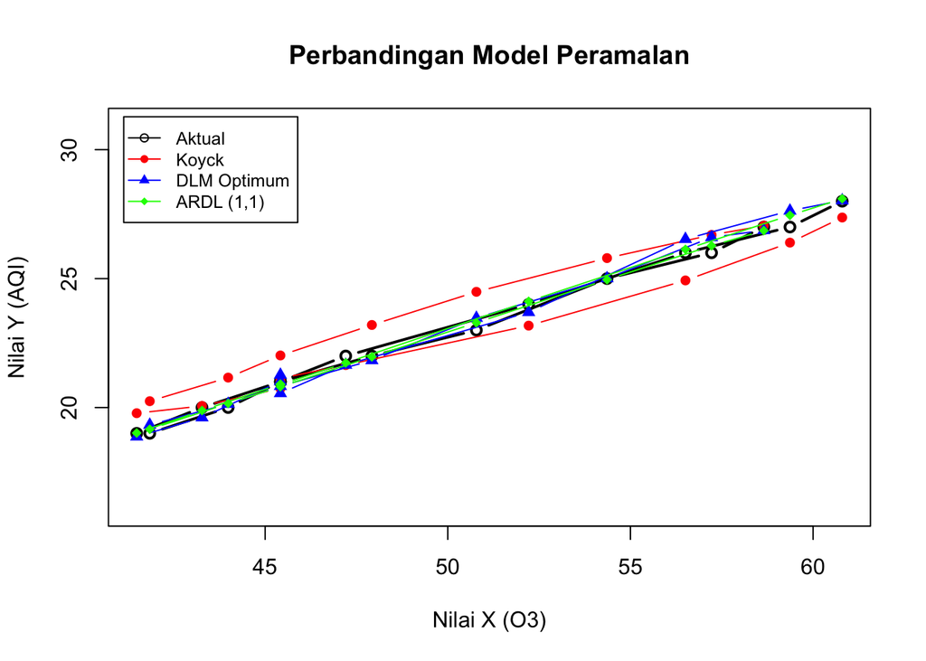

```r
par(mfrow=c(1,1))
plot(test$Xt, test$Yt, type="b", col="black",
     ylim=c(min(test$Yt)-3, max(test$Yt)+3),
     lwd=2, ylab="Nilai Y (AQI)", xlab="Nilai X (O3)", main="Perbandingan Model Peramalan")

lines(test$Xt, fore.koyck$forecasts, col="red", type="b", pch=16)
lines(test$Xt, fore.dlm.opt$forecasts, col="blue", type="b", pch=17)
lines(test$Xt, fore.ardl$forecasts, col="green", type="b", pch=18)

legend("topleft", legend=c("Aktual", "Koyck", "DLM Optimum", "ARDL (1,1)"),
       col=c("black","red","blue","green"), lty=1, pch=c(1,16,17,18), cex=0.8, inset=0.02)
```